# R-Ladies Jakarta 8th Meetup: Intro to Twitter Mining in R

Erika Siregar [<@erikaris>](https://twitter.com/erikaris)

7/18/2020

## How to get Twitter Data

- Step 1: Setup your account
- Step 2: Download/extract data
- Step 3: Analyze and visualize

## Setting Up Your Twitter Account

Please refer to https://github.com/RLadiesJakarta/meetup_8_intro_twitter_likert_vis/blob/master/settingup_twitter_account.md

## Obtaining Data from Twitter

### Prepare the Library

```r
library(rtweet)        # R client for accessing Twitter's REST and stream APIs
library(wordcloud)     # for creating wordcloud
library(dplyr)         # dplyr
library(igraph)        # for creating network graph
library(tm)            # for text mining
library(RColorBrewer)  # for coloring things
library(qdapRegex)       # for regex
library(qdap)
library(maps)
```

### Create Oauth (Twitter API) token.

```r
# create token named 'mytoken'
mytoken <- create_token( app = "mytwitterapp", # you can change the app name
                         consumer_key = "your consumer key",
                         consumer_secret = "your consumer secret",
                         access_token = "your access token",
                         access_secret = "your access token secret"
                         )
```

Example:

```r
# create token named 'mytoken'
mytoken <- create_token( app = "rladiesjkt", # you can change the app name
                         consumer_key = "rqVT4hxIZnSmsxy8ZevGfPjdQ",
                         consumer_secret = "FYwwjBygIwjHQP52q0uDQHqgNABLVIeEgRb0MFelQoXeaRzsZ9",
                         access_token = "284205655-TYp8cJPo45g5dseIAwtbaECS5DwJGaPpCYc1hAjI",
                         access_secret = "Qb7mzFoAog9jRkNBUIxUJGjIiShC3d8nTlZ7VW60uIWkJ"
                         )
```

### Collecting The Tweets

There are two function that we can choose in order to acquire twitter data:

1. `stream_tweets()`: catches the tweet for current checkpoint until timeout, so with `stream_tweets()` we are moving forward and obtain the most up-to-date tweets.
2. `search_tweets()`: from the current checkpoint backward.

### Stream Tweets

Usage:

```r
my_tweets = stream_tweets(q = "", timeout = 30, token = NULL)
```

Notes:

1. q = “keyword”, can be a keyword or screen name (up to 400 keywords, comma separated). Example: `stream_tweets("covid19", timeout = 60)`, `stream_tweets("erikaris", timeout = 90)`
2. timeout = define how long the tweet streaming will last (in seconds). To stream indefinitely, use timeout = FALSE.
3. token = the Oauth (Twitter API) token created on the previous step.

The `stream_tweets()` returns a dataframe consist of `number_of_tweet` rows and 90 columns.

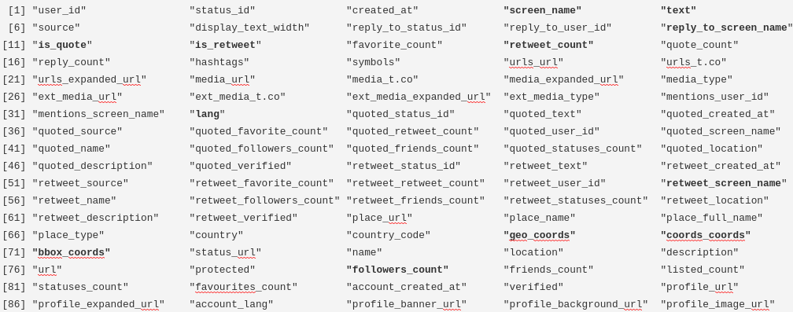

.

Example:

```r
tweet60 <- stream_tweets("jokowi", timeout = 60, token = mytoken)
head(tweet60)
```

```
## # A tibble: 6 x 90
##   user_id status_id created_at          screen_name text  source
##   <chr>   <chr>     <dttm>              <chr>       <chr> <chr>
## 1 125100… 12843749… 2020-07-18 06:30:28 arya244200… "Mar… Twitt…
## 2 125100… 12843751… 2020-07-18 06:31:18 arya244200… "#FA… Twitt…
## 3 125100… 12843749… 2020-07-18 06:30:36 arya244200… "Jad… Twitt…
## 4 125100… 12843750… 2020-07-18 06:30:51 arya244200… "#fa… Twitt…
## 5 129347… 12843749… 2020-07-18 06:30:28 Masartono   "Sy … Twitt…
## 6 116747… 12843749… 2020-07-18 06:30:28 siskanlv    "Ass… Twitt…
## # … with 84 more variables: display_text_width <dbl>, reply_to_status_id <chr>,
## #   reply_to_user_id <chr>, reply_to_screen_name <chr>, is_quote <lgl>,
## #   is_retweet <lgl>, favorite_count <int>, retweet_count <int>,
## #   quote_count <int>, reply_count <int>, hashtags <list>, symbols <list>,
## #   urls_url <list>, urls_t.co <list>, urls_expanded_url <list>,
## #   media_url <list>, media_t.co <list>, media_expanded_url <list>,
## #   media_type <list>, ext_media_url <list>, ext_media_t.co <list>,
## #   ext_media_expanded_url <list>, ext_media_type <chr>,
## #   mentions_user_id <list>, mentions_screen_name <list>, lang <chr>,
## #   quoted_status_id <chr>, quoted_text <chr>, quoted_created_at <dttm>,
## #   quoted_source <chr>, quoted_favorite_count <int>,
## #   quoted_retweet_count <int>, quoted_user_id <chr>, quoted_screen_name <chr>,
## #   quoted_name <chr>, quoted_followers_count <int>,
## #   quoted_friends_count <int>, quoted_statuses_count <int>,
## #   quoted_location <chr>, quoted_description <chr>, quoted_verified <lgl>,
## #   retweet_status_id <chr>, retweet_text <chr>, retweet_created_at <dttm>,
## #   retweet_source <chr>, retweet_favorite_count <int>,
## #   retweet_retweet_count <int>, retweet_user_id <chr>,
## #   retweet_screen_name <chr>, retweet_name <chr>,
## #   retweet_followers_count <int>, retweet_friends_count <int>,
## #   retweet_statuses_count <int>, retweet_location <chr>,
## #   retweet_description <chr>, retweet_verified <lgl>, place_url <chr>,
## #   place_name <chr>, place_full_name <chr>, place_type <chr>, country <chr>,
## #   country_code <chr>, geo_coords <list>, coords_coords <list>,
## #   bbox_coords <list>, status_url <chr>, name <chr>, location <chr>,
## #   description <chr>, url <chr>, protected <lgl>, followers_count <int>,
## #   friends_count <int>, listed_count <int>, statuses_count <int>,
## #   favourites_count <int>, account_created_at <dttm>, verified <lgl>,
## #   profile_url <chr>, profile_expanded_url <chr>, account_lang <lgl>,
## #   profile_banner_url <chr>, profile_background_url <chr>,
## #   profile_image_url <chr>
```

### Search Tweets

`search_tweets()` returns a maximum of *18,000* tweets for each request posted. Usage: `search_tweets(q, n = 100, include_rts = FALSE)`.

Notes:

1. q = query of the tweets to be searched.
2. n = integer –> number of desired tweets to download.
3. include_rts = logical –> if TRUE, it means include retweets in search results.

The `search_tweets()` returns a dataframe similar to that of generated by `stream_tweets()`.

Example:

```r
jokowi <- search_tweets("jokowi", n = 10000, lang = "id")
head(jokowi)
```

```
## # A tibble: 6 x 90
##   user_id status_id created_at          screen_name text  source
##   <chr>   <chr>     <dttm>              <chr>       <chr> <chr>
## 1 114749… 12843752… 2020-07-18 06:31:30 Hmmurahmur… "REZ… Twitt…
## 2 114749… 12843735… 2020-07-18 06:24:48 Hmmurahmur… "Sek… Twitt…
## 3 114749… 12843747… 2020-07-18 06:29:32 Hmmurahmur… "@Mi… Twitt…
## 4 128268… 12843752… 2020-07-18 06:31:30 Amz_4n6     "Jad… Twitt…
## 5 107782… 12843752… 2020-07-18 06:31:29 goldennglow "Sel… Twitt…
## 6 125100… 12843752… 2020-07-18 06:31:28 arya244200… "Ass… Twitt…
## # … with 84 more variables: display_text_width <dbl>, reply_to_status_id <chr>,
## #   reply_to_user_id <chr>, reply_to_screen_name <chr>, is_quote <lgl>,
## #   is_retweet <lgl>, favorite_count <int>, retweet_count <int>,
## #   quote_count <int>, reply_count <int>, hashtags <list>, symbols <list>,
## #   urls_url <list>, urls_t.co <list>, urls_expanded_url <list>,
## #   media_url <list>, media_t.co <list>, media_expanded_url <list>,
## #   media_type <list>, ext_media_url <list>, ext_media_t.co <list>,
## #   ext_media_expanded_url <list>, ext_media_type <chr>,
## #   mentions_user_id <list>, mentions_screen_name <list>, lang <chr>,
## #   quoted_status_id <chr>, quoted_text <chr>, quoted_created_at <dttm>,
## #   quoted_source <chr>, quoted_favorite_count <int>,
## #   quoted_retweet_count <int>, quoted_user_id <chr>, quoted_screen_name <chr>,
## #   quoted_name <chr>, quoted_followers_count <int>,
## #   quoted_friends_count <int>, quoted_statuses_count <int>,
## #   quoted_location <chr>, quoted_description <chr>, quoted_verified <lgl>,
## #   retweet_status_id <chr>, retweet_text <chr>, retweet_created_at <dttm>,
## #   retweet_source <chr>, retweet_favorite_count <int>,
## #   retweet_retweet_count <int>, retweet_user_id <chr>,
## #   retweet_screen_name <chr>, retweet_name <chr>,
## #   retweet_followers_count <int>, retweet_friends_count <int>,
## #   retweet_statuses_count <int>, retweet_location <chr>,
## #   retweet_description <chr>, retweet_verified <lgl>, place_url <chr>,
## #   place_name <chr>, place_full_name <chr>, place_type <chr>, country <chr>,
## #   country_code <chr>, geo_coords <list>, coords_coords <list>,
## #   bbox_coords <list>, status_url <chr>, name <chr>, location <chr>,
## #   description <chr>, url <chr>, protected <lgl>, followers_count <int>,
## #   friends_count <int>, listed_count <int>, statuses_count <int>,
## #   favourites_count <int>, account_created_at <dttm>, verified <lgl>,
## #   profile_url <chr>, profile_expanded_url <chr>, account_lang <lgl>,
## #   profile_banner_url <chr>, profile_background_url <chr>,
## #   profile_image_url <chr>
```

### Extracting User Information

Usage: `users_data(tweets)`.

Notes: tweets is a tweet dataframe obtained from the collecting tweets done in the previous step.

This will return a tibble dataframe consists of n rows (observations) and 20 columns (variables).  
The number of rows (n) will be equal to the number of users involved in the collected tweet object.

Example:

```r
usrdt <- users_data(jokowi)
head(usrdt)
```

```
## # A tibble: 6 x 20
##   user_id screen_name name  location description url   protected followers_count
##   <chr>   <chr>       <chr> <chr>    <chr>       <chr> <lgl>               <int>
## 1 114749… Hmmurahmur… Hmmu… "Kebume… "Wira Usah… <NA>  FALSE                3265
## 2 114749… Hmmurahmur… Hmmu… "Kebume… "Wira Usah… <NA>  FALSE                3265
## 3 114749… Hmmurahmur… Hmmu… "Kebume… "Wira Usah… <NA>  FALSE                3265
## 4 128268… Amz_4n6     Am P… ""       "Uncreativ… <NA>  FALSE                 174
## 5 107782… goldennglow 🌝    "Yogyak… "Pedagang … <NA>  FALSE                  94
## 6 125100… arya244200… Widya ""       ""          <NA>  FALSE                   0
## # … with 12 more variables: friends_count <int>, listed_count <int>,
## #   statuses_count <int>, favourites_count <int>, account_created_at <dttm>,
## #   verified <lgl>, profile_url <chr>, profile_expanded_url <chr>,
## #   account_lang <lgl>, profile_banner_url <chr>, profile_background_url <chr>,
## #   profile_image_url <chr>
```

```r
names(usrdt)
```

```
##  [1] "user_id"                "screen_name"            "name"
##  [4] "location"               "description"            "url"
##  [7] "protected"              "followers_count"        "friends_count"
## [10] "listed_count"           "statuses_count"         "favourites_count"
## [13] "account_created_at"     "verified"               "profile_url"
## [16] "profile_expanded_url"   "account_lang"           "profile_banner_url"
## [19] "profile_background_url" "profile_image_url"
```

## Analyzing the Tweets (Mari Berkepo Ria)

### Find Users Who Tweets the Most about Certain Topics

```r
# step 1: Create a table of users and tweet counts for the topic
jokowi_user <- table(jokowi$screen_name)

# step 2: sort the table in descending order of tweet counts
jokowi_user_sort <- sort(jokowi_user, decreasing = TRUE)

# step 3: View sorted table for top 10 users
head(jokowi_user_sort, 10)
```

```
##
##      ErfanMaada      azis_soleh    haninhilbram MDR_l205bl7____   cukup1periode
##              55              36              32              28              27
##     nonhellyeah  King_El_Montes AhmadSuriansy13           egafi         teaenak
##              25              22              21              21              21
```

### Compare The Number of Followers between Certain Users

To do this, we take advantage of using `lookup_users()` function.

```r
# get the data of intended users
mypeople <- lookup_users(c("erikaris", "ulfahregar", "rladiesjakarta", "akkuderry", "gwangge", "ikakarlina", "r_indonesia_", "rladiesbogor"))

# take only columns "screen_name", "followers_count"
mypeople_count <- mypeople[, c("screen_name", "followers_count")]

# order by followers_count (decreasing)
mypeople_count <- mypeople_count[order(-mypeople_count$followers_count), ]

mypeople_count
```

```
## # A tibble: 8 x 2
##   screen_name    followers_count
##   <chr>                    <int>
## 1 ikakarlina                 781
## 2 akkuderry                  714
## 3 r_indonesia_               466
## 4 erikaris                   292
## 5 ulfahregar                 286
## 6 gwangge                    246
## 7 RLadiesJakarta             197
## 8 RLadiesBogor                72
```

### Counting The Number of Retwets

```r
library(dplyr)

rtwt <- jokowi[, c("text", "retweet_count")]
rtwt_sort <- arrange(rtwt, desc(retweet_count))
head(rtwt_sort)
```

```
## # A tibble: 6 x 2
##   text                                                             retweet_count
##   <chr>                                                                    <int>
## 1 "Sandiwara telah selesai sesuai dgn skenarionya. \nPoint pembel…         15717
## 2 "Sandiwara telah selesai sesuai dgn skenarionya. \nPoint pembel…         15717
## 3 "Sandiwara telah selesai sesuai dgn skenarionya. \nPoint pembel…         15717
## 4 "Sandiwara telah selesai sesuai dgn skenarionya. \nPoint pembel…         15717
## 5 "Sandiwara telah selesai sesuai dgn skenarionya. \nPoint pembel…         15717
## 6 "Sandiwara telah selesai sesuai dgn skenarionya. \nPoint pembel…         15717
```

## Analyzing Twitter Trend

### Get The Trend

```r
trend_jkt <- get_trends("Jakarta")
head(trend_jkt)
```

```
## # A tibble: 6 x 9
##   trend url   promoted_content query tweet_volume place  woeid
##   <chr> <chr> <lgl>            <chr>        <int> <chr>  <int>
## 1 #far… http… NA               %23f…           NA Jaka… 1.05e6
## 2 #Ber… http… NA               %23B…           NA Jaka… 1.05e6
## 3 #JHO… http… NA               %23J…        46273 Jaka… 1.05e6
## 4 LAH … http… NA               %22L…           NA Jaka… 1.05e6
## 5 #Mil… http… NA               %23M…           NA Jaka… 1.05e6
## 6 Haru… http… NA               %22H…           NA Jaka… 1.05e6
## # … with 2 more variables: as_of <dttm>, created_at <dttm>
```

### Visualize the Trend

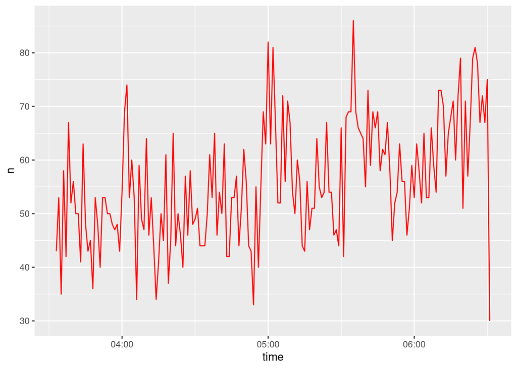

```r
ts_plot(jokowi, by = 'mins', color = 'red')
```

### Counting frequency of tweets over a specified time interval

```r
ts_data(jokowi, by = "hours")
```

```
## # A tibble: 4 x 2
##   time                    n
##   <dttm>              <int>
## 1 2020-07-18 03:00:00  1315
## 2 2020-07-18 04:00:00  3062
## 3 2020-07-18 05:00:00  3556
## 4 2020-07-18 06:00:00  2059
```

## Mining the Twitter Text

1. Extract the text only from the tweets dataset

```r
head(jokowi$text)
```

```
## [1] "REZIM JOKOWI = REZIM GENOSIDA!\n\nCorona dipakai alasan untuk korupsi APBN gila2an. Rakyat dibikin susah terus.\n\nLockdown lebih awal = cegah penyebaran lebih awal. Dasar rezim Jokowi maling APBN kerjanya nipu rakyat!\n\nhttps://t.co/iXQ4yHqE0K\n\n#IndonesiaSudahBangkrut"
## [2] "Sekitar akhir Mei 2019 saya dikasih tahu oleh kawan bahwa Dukun Jokowi nyuruh Jokowi untuk rangkul PS karena PS yang pegang kunci dana triliunan di LN. \n\nJokowi terus numpuk utang.  Dalam rangka ngabisin duit yang dijanjikan dukun itu?\n\nBAJINGAAAANNN!!!\n\n#IndonesiaSudahBangkrut"
## [3] "@MichelAdamADA_ Kalau Dukun sudah dipercaya maka bencana akan semakin nyata. Untuk menghindari itu tak ada jalan lain LENGSERKAN JOKOWI\n#IndonesiaSudahBangkrut\n#IndonesiaSudahBangkrut 1"
## [4] "Jadi klu ditanya siapa yg paling kesal sama Covid ini, ya bukan Pak Jokowi atau bu Sri Mulyani.\n\nTapi ya dokter2 dan Nakes lainnya.\n\nPenghasilan drop, risiko bertambah karena harus bertemu pasien covid, lihat masyarakat degil2 plus ditambah tuduhan dokter tambah kaya krena Covid"
## [5] "Selain bisnis mebel, juga \"dagang sapi\". https://t.co/Vt077O44vU"
## [6] "Assalamualaikum Wr.wb\nHidup Mahasiswa \nHidup Farmasi Indonesia\n\nSeruan Aksi Online !!!\n#FarmasisKecewa\n#Pray4Farmasis\n\nMention ke akun @jokowi @dpr_ri @najwashihab @mastercorbuzier @ismafarsi @ppiai\n\n(Sebarkan pesan ini ke seluruh keluarga, kerabat &amp; teman2 tanpa terkecuali) ht…
```

2. Remove the URLs from the text. Use function `rm_twitter_url()` from library qdapRegex.

```r
jokowi_textrm <- rm_twitter_url(jokowi$text)
head(jokowi_textrm)
```

```
## [1] "REZIM JOKOWI = REZIM GENOSIDA! Corona dipakai alasan untuk korupsi APBN gila2an. Rakyat dibikin susah terus. Lockdown lebih awal = cegah penyebaran lebih awal. Dasar rezim Jokowi maling APBN kerjanya nipu rakyat!"
## [2] "Sekitar akhir Mei 2019 saya dikasih tahu oleh kawan bahwa Dukun Jokowi nyuruh Jokowi untuk rangkul PS karena PS yang pegang kunci dana triliunan di LN. Jokowi terus numpuk utang. Dalam rangka ngabisin duit yang dijanjikan dukun itu? BAJINGAAAANNN!!! #IndonesiaSudahBangkrut"
## [3] "@MichelAdamADA_ Kalau Dukun sudah dipercaya maka bencana akan semakin nyata. Untuk menghindari itu tak ada jalan lain LENGSERKAN JOKOWI #IndonesiaSudahBangkrut #IndonesiaSudahBangkrut 1"
## [4] "Jadi klu ditanya siapa yg paling kesal sama Covid ini, ya bukan Pak Jokowi atau bu Sri Mulyani. Tapi ya dokter2 dan Nakes lainnya. Penghasilan drop, risiko bertambah karena harus bertemu pasien covid, lihat masyarakat degil2 plus ditambah tuduhan dokter tambah kaya krena Covid"
## [5] "Selain bisnis mebel, juga \"dagang sapi\"."
## [6] "Assalamualaikum Wr.wb Hidup Mahasiswa Hidup Farmasi Indonesia Seruan Aksi Online !!! #FarmasisKecewa #Pray4Farmasis Mention ke akun @jokowi @dpr_ri @najwashihab @mastercorbuzier @ismafarsi @ppiai (Sebarkan pesan ini ke seluruh keluarga, kerabat &amp; teman2 tanpa terkecuali)"
```

3. Remove special characters, punctuation, & numbers from the output of the previous step. Use the function `gsub(pattern)`.

```r
jokowi_text_gsub <- gsub("[^A-Za-z]"," " , jokowi_textrm)
head(jokowi_text_gsub)
```

```
## [1] "REZIM JOKOWI   REZIM GENOSIDA  Corona dipakai alasan untuk korupsi APBN gila an  Rakyat dibikin susah terus  Lockdown lebih awal   cegah penyebaran lebih awal  Dasar rezim Jokowi maling APBN kerjanya nipu rakyat "
## [2] "Sekitar akhir Mei      saya dikasih tahu oleh kawan bahwa Dukun Jokowi nyuruh Jokowi untuk rangkul PS karena PS yang pegang kunci dana triliunan di LN  Jokowi terus numpuk utang  Dalam rangka ngabisin duit yang dijanjikan dukun itu  BAJINGAAAANNN     IndonesiaSudahBangkrut"
## [3] " MichelAdamADA  Kalau Dukun sudah dipercaya maka bencana akan semakin nyata  Untuk menghindari itu tak ada jalan lain LENGSERKAN JOKOWI  IndonesiaSudahBangkrut  IndonesiaSudahBangkrut  "
## [4] "Jadi klu ditanya siapa yg paling kesal sama Covid ini  ya bukan Pak Jokowi atau bu Sri Mulyani  Tapi ya dokter  dan Nakes lainnya  Penghasilan drop  risiko bertambah karena harus bertemu pasien covid  lihat masyarakat degil  plus ditambah tuduhan dokter tambah kaya krena Covid"
## [5] "Selain bisnis mebel  juga  dagang sapi  "
## [6] "Assalamualaikum Wr wb Hidup Mahasiswa Hidup Farmasi Indonesia Seruan Aksi Online      FarmasisKecewa  Pray Farmasis Mention ke akun  jokowi  dpr ri  najwashihab  mastercorbuzier  ismafarsi  ppiai  Sebarkan pesan ini ke seluruh keluarga  kerabat  amp  teman  tanpa terkecuali "
```

```r
str(jokowi_text_gsub)
```

```
##  chr [1:9992] "REZIM JOKOWI   REZIM GENOSIDA  Corona dipakai alasan untuk korupsi APBN gila an  Rakyat dibikin susah terus  Lo"| __truncated__ ...
```

4. Create corpus

In library `tm`, text must be converted into a corpus object so that we can apply various treatments on it later, such as lowercasing or stripping whitespace.

```r
library("tm")
# Convert text in "twt_gsub" dataset to a text corpus and view output
jokowi_corpus <- jokowi_text_gsub %>%
                  VectorSource() %>%  # change the list of elements into vector's document
                  Corpus()     # turn the vector into a corpus

head(jokowi_corpus)
head(jokowi_corpus$content)
```

[output not shown]

5. Lower case the text

```r
library("tm")
# Convert text in "twt_gsub" dataset to a text corpus and view output
jokowi_corpus <- jokowi_text_gsub %>%
                  VectorSource() %>%  # change the list of elements into vector's document
                  Corpus() %>%        # turn the vector into a corpus
                  tm_map(tolower)
head(jokowi_corpus$content)   # focus on the corpus$content
```

```
## [1] "rezim jokowi   rezim genosida  corona dipakai alasan untuk korupsi apbn gila an  rakyat dibikin susah terus  lockdown lebih awal   cegah penyebaran lebih awal  dasar rezim jokowi maling apbn kerjanya nipu rakyat "
## [2] "sekitar akhir mei      saya dikasih tahu oleh kawan bahwa dukun jokowi nyuruh jokowi untuk rangkul ps karena ps yang pegang kunci dana triliunan di ln  jokowi terus numpuk utang  dalam rangka ngabisin duit yang dijanjikan dukun itu  bajingaaaannn     indonesiasudahbangkrut"
## [3] " micheladamada  kalau dukun sudah dipercaya maka bencana akan semakin nyata  untuk menghindari itu tak ada jalan lain lengserkan jokowi  indonesiasudahbangkrut  indonesiasudahbangkrut  "
## [4] "jadi klu ditanya siapa yg paling kesal sama covid ini  ya bukan pak jokowi atau bu sri mulyani  tapi ya dokter  dan nakes lainnya  penghasilan drop  risiko bertambah karena harus bertemu pasien covid  lihat masyarakat degil  plus ditambah tuduhan dokter tambah kaya krena covid"
## [5] "selain bisnis mebel  juga  dagang sapi  "
## [6] "assalamualaikum wr wb hidup mahasiswa hidup farmasi indonesia seruan aksi online      farmasiskecewa  pray farmasis mention ke akun  jokowi  dpr ri  najwashihab  mastercorbuzier  ismafarsi  ppiai  sebarkan pesan ini ke seluruh keluarga  kerabat  amp  teman  tanpa terkecuali "
```

6. Stripping whitespace

```r
library("tm")
# Convert text in "twt_gsub" dataset to a text corpus and view output
jokowi_corpus <- jokowi_text_gsub %>%
                  VectorSource() %>%  # change the list of elements into vector's document
                  Corpus() %>%        # turn the vector into a corpus
                  tm_map(tolower) %>%  # lower case the text
                  tm_map(stripWhitespace)  # remove unnecessary whitespace
head(jokowi_corpus$content)   # focus on the corpus$content
```

```
## [1] "rezim jokowi rezim genosida corona dipakai alasan untuk korupsi apbn gila an rakyat dibikin susah terus lockdown lebih awal cegah penyebaran lebih awal dasar rezim jokowi maling apbn kerjanya nipu rakyat "
## [2] "sekitar akhir mei saya dikasih tahu oleh kawan bahwa dukun jokowi nyuruh jokowi untuk rangkul ps karena ps yang pegang kunci dana triliunan di ln jokowi terus numpuk utang dalam rangka ngabisin duit yang dijanjikan dukun itu bajingaaaannn indonesiasudahbangkrut"
## [3] " micheladamada kalau dukun sudah dipercaya maka bencana akan semakin nyata untuk menghindari itu tak ada jalan lain lengserkan jokowi indonesiasudahbangkrut indonesiasudahbangkrut "
## [4] "jadi klu ditanya siapa yg paling kesal sama covid ini ya bukan pak jokowi atau bu sri mulyani tapi ya dokter dan nakes lainnya penghasilan drop risiko bertambah karena harus bertemu pasien covid lihat masyarakat degil plus ditambah tuduhan dokter tambah kaya krena covid"
## [5] "selain bisnis mebel juga dagang sapi "
## [6] "assalamualaikum wr wb hidup mahasiswa hidup farmasi indonesia seruan aksi online farmasiskecewa pray farmasis mention ke akun jokowi dpr ri najwashihab mastercorbuzier ismafarsi ppiai sebarkan pesan ini ke seluruh keluarga kerabat amp teman tanpa terkecuali "
```

7. remove stopwords.

Stop words are commonly used words that are excluded from searches to help index and parse web pages faster.  
Available stopwords library are mostly for English language.  
There is [Sastrawi](http://sastrawi.github.io/) for Indonesian but it’s for python and hasn’t been updated for 4 years.  
Create our own stopwords library.

```r
library("tm")

# taken from https://github.com/sastrawi/sastrawi/blob/master/src/Sastrawi/StopWordRemover/StopWordRemoverFactory.php

custom_stopwds <- c('yang', 'untuk', 'pada', 'ke', 'para', 'namun', 'menurut', 'antara', 'dia', 'dua', 'ia', 'seperti', 'jika', 'jika', 'sehingga', 'kembali', 'dan', 'tidak', 'ini', 'karena', 'kepada', 'oleh', 'saat', 'harus', 'sementara', 'setelah', 'belum', 'kami', 'sekitar', 'bagi', 'serta', 'di', 'dari', 'telah', 'sebagai', 'masih', 'hal', 'ketika', 'adalah', 'itu', 'dalam', 'bisa', 'bahwa', 'atau', 'hanya', 'kita', 'dengan', 'akan', 'juga', 'ada', 'mereka', 'sudah', 'saya', 'terhadap', 'secara', 'agar', 'lain', 'anda', 'begitu', 'mengapa', 'kenapa', 'yaitu', 'yakni', 'daripada', 'itulah', 'lagi', 'maka', 'tentang', 'demi', 'dimana', 'kemana', 'pula', 'sambil', 'sebelum', 'sesudah', 'supaya', 'guna', 'kah', 'pun', 'sampai', 'sedangkan', 'selagi', 'sementara', 'tetapi', 'apakah', 'kecuali', 'sebab', 'selain', 'seolah', 'seraya', 'seterusnya', 'tanpa', 'agak', 'boleh', 'dapat', 'dsb', 'dst', 'dll', 'dahulu', 'dulunya', 'anu', 'demikian', 'tapi', 'ingin', 'juga', 'nggak', 'mari', 'nanti', 'melainkan', 'oh', 'ok', 'seharusnya', 'sebetulnya', 'setiap', 'setidaknya', 'sesuatu', 'pasti', 'saja', 'toh', 'ya', 'walau', 'tolong', 'tentu', 'amat', 'apalagi', 'bagaimanapun')

# Convert text in "twt_gsub" dataset to a text corpus and view output
jokowi_corpus <- jokowi_text_gsub %>%
                  VectorSource() %>%  # change the list of elements into vector's document
                  Corpus() %>%        # turn the vector into a corpus
                  tm_map(tolower) %>%  # lower case the text
                  tm_map(stripWhitespace) %>%  # remove unnecessary whitespace
                  tm_map(removeWords, custom_stopwds)  # remove stopwords

head(jokowi_corpus$content)   # focus on the corpus$content
```

```
## [1] "rezim jokowi rezim genosida corona dipakai alasan  korupsi apbn gila an rakyat dibikin susah terus lockdown lebih awal cegah penyebaran lebih awal dasar rezim jokowi maling apbn kerjanya nipu rakyat "
## [2] " akhir mei  dikasih tahu  kawan  dukun jokowi nyuruh jokowi  rangkul ps  ps  pegang kunci dana triliunan  ln jokowi terus numpuk utang  rangka ngabisin duit  dijanjikan dukun  bajingaaaannn indonesiasudahbangkrut"
## [3] " micheladamada kalau dukun  dipercaya  bencana  semakin nyata  menghindari  tak  jalan  lengserkan jokowi indonesiasudahbangkrut indonesiasudahbangkrut "
## [4] "jadi klu ditanya siapa yg paling kesal sama covid   bukan pak jokowi  bu sri mulyani   dokter  nakes lainnya penghasilan drop risiko bertambah   bertemu pasien covid lihat masyarakat degil plus ditambah tuduhan dokter tambah kaya krena covid"
## [5] " bisnis mebel  dagang sapi "
## [6] "assalamualaikum wr wb hidup mahasiswa hidup farmasi indonesia seruan aksi online farmasiskecewa pray farmasis mention  akun jokowi dpr ri najwashihab mastercorbuzier ismafarsi ppiai sebarkan pesan   seluruh keluarga kerabat amp teman  terkecuali "
```

## Visualization

### Bar Graph

Top 10 Words

```r
library(qdap)

# Extract term frequencies for the top 10 words
termfreq10 <- freq_terms(jokowi_corpus$content, 10)
termfreq10
```

```
##    WORD     FREQ
## 1  jokowi   9964
## 2  anak     3945
## 3  solo     2303
## 4  yg       2232
## 5  politik  2105
## 6  maju     1970
## 7  pak      1512
## 8  dinasti  1499
## 9  presiden 1344
## 10 guru     1306
```

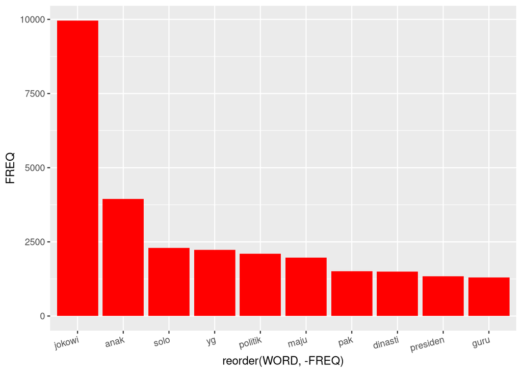

```r
# Create a bar plot using terms with more than 60 counts
ggplot(termfreq10, aes(x = reorder(WORD, -FREQ), y = FREQ)) +
        geom_bar(stat = "identity", fill = "red") +
        theme(axis.text.x = element_text(angle = 15, hjust = 1))
```

### Wordcloud

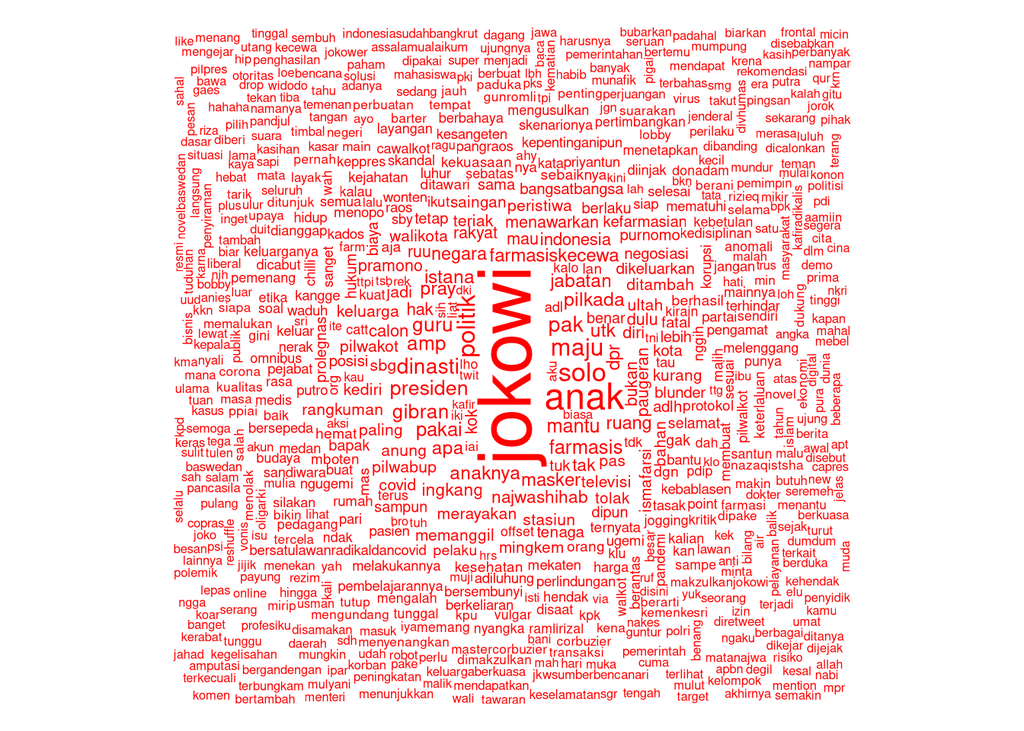

```r
library(wordcloud)
# Create a word cloud in red with min frequency of 20
wordcloud(jokowi_corpus$content, min.freq = 20, colors = "red",
    scale = c(3,0.5),random.order = FALSE)
```

#### Fancy for some colors?

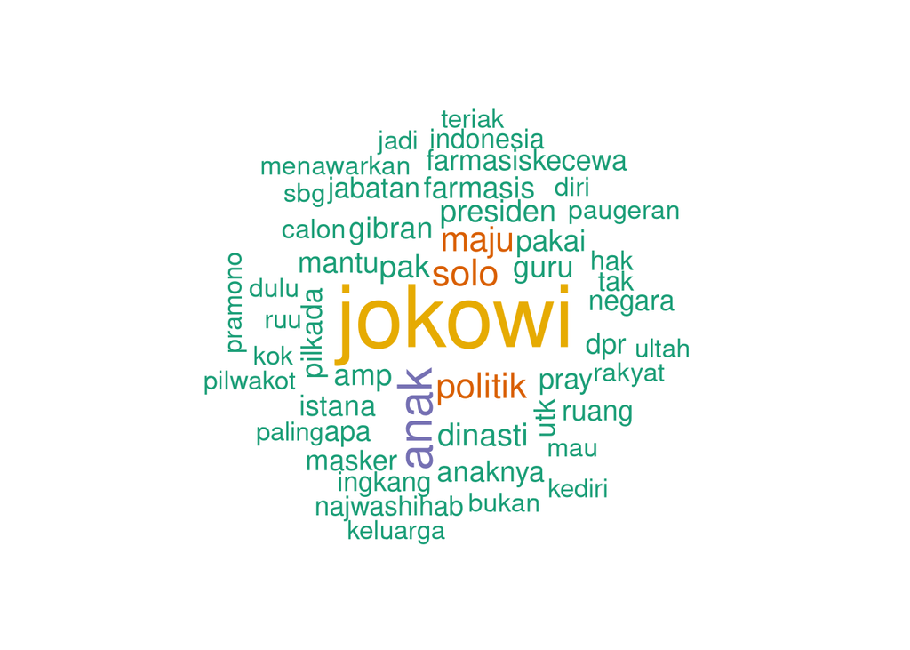

```r
library(wordcloud)
library(RColorBrewer)

# Create word cloud with 6 colors and max 50 words
wordcloud(jokowi_corpus$content, max.words = 50,
    colors = brewer.pal(6, "Dark2"),
    scale=c(4,1), random.order = FALSE)
```

## When in doubt, see it on map

For now, the `maps()` package can only support few regions: world, states, nz, france, italy, and canada.

Indonesia ???

```r
library(maps)

# Extract geo-coordinates data to append as new columns
jokowi_coord <- lat_lng(jokowi)

# View the columns with geo-coordinates for first 20 tweets
head(jokowi_coord[c("lat","lng")], 20)
```

```
## # A tibble: 20 x 2
##      lat   lng
##    <dbl> <dbl>
##  1    NA    NA
##  2    NA    NA
##  3    NA    NA
##  4    NA    NA
##  5    NA    NA
##  6    NA    NA
##  7    NA    NA
##  8    NA    NA
##  9    NA    NA
## 10    NA    NA
## 11    NA    NA
## 12    NA    NA
## 13    NA    NA
## 14    NA    NA
## 15    NA    NA
## 16    NA    NA
## 17    NA    NA
## 18    NA    NA
## 19    NA    NA
## 20    NA    NA
```

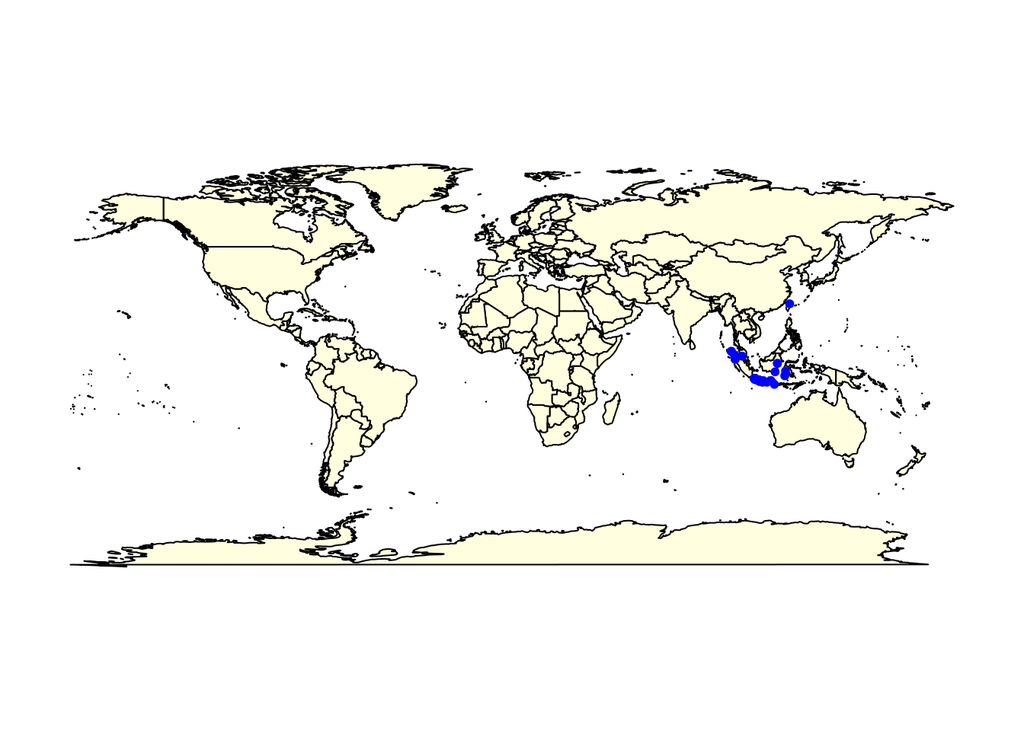

```r
jokowi_geo <- na.omit(jokowi_coord[,c("lat", "lng")])

# Plot longitude and latitude values of tweets on the US state map
map(database = 'world', fill = TRUE, col = 'light yellow')
with(jokowi_geo, points(lng, lat, pch = 20, cex = 1, col = 'blue'))
```